# 2017 Repair dental restorations

Data extracted was tabulated in a google sheet. Then exported as csv file and imported in R (R Core Team (2017). R: A language and environment for statistical computing. R Foundation for Statistical Computing, Vienna, Austria. URL https://www.R-project.org/.)

Data cleaning and organization was done with package tidyverse (Hadley Wickham (2017). tidyverse: Easily Install and Load the ‘Tidyverse’. R package version 1.2.1. https://CRAN.R-project.org/package=tidyverse).

The package meta (Guido Schwarzer (2007), meta: An R package for meta-analysis, R News, 7(3), 40-45.) was used for the meta-analysis. A funnel plot was used to detect publication bias. The heterogenicity between studies was checked with I2 and visualized with a Baujat plot (Baujat B, Mahé C, Pignon JP, Hill C (2002), A graphical method for exploring heterogeneity in meta-analyses: Application to a meta-analysis of 65 trials. Statistics in Medicine, 30, 2641–2652.). We grouped the studies with same intervention and control and considered any adverse outcome. A random effect meta-analysis using odds-ratio as outcome was performed with a Mantel-Haenzel method. A forest plot was used to visualize the overall effect of the interventions, with a 95% confidence interval.

# Dataset

```r
df <- read_csv("https://docs.google.com/spreadsheets/d/e/2PACX-1vRSKuBlcQTVJK2fZyZ4Nvf4SwSqVrxcfAGhNhl6dWHU9W39oppE4Pl4lcPy-0CRGRTqQQ0IHwFgfrY8/pub?gid=0&single=true&output=csv")
```

## Data cleaning

```r
glimpse(df)
```

Clean dataset from empty rows, strange symbols, etc

```r
df <- df %>% filter(str_detect(df$Comparison, "vs"),
                      trimws(EvA) != "",
                    !str_detect(EvA, "\\?"),
                    !str_detect(EvA, "%") )

df$firstAuthor <- str_trim(df$firstAuthor, "right")
```

Select only relevant columns

```r
df <- df %>% select(Comparison:Outcome) %>%
  select(-quality)
```

create a new column id

```r
df <-  mutate(df, id = paste(firstAuthor, ", ", year, paper))
```

## Dataset clean

Converting factors to numeric variables

```r
glimpse(df)

df$EvA <- as.integer(df$EvA)
df$TotalA <- as.integer(df$TotalA)
df$EvB <- as.integer(df$EvB)
df$TotalB <- as.integer(df$TotalB)

df <- df %>%
  mutate(groups = paste(Comparison, Outcome))
```

```r
summary(df)
```

Create groups for comparisons

Any intervention (Sealant, Refinishing or Repair) vs grouped comparison and grouped outcome

```r
df <- mutate(df, groups = paste( intervention_b, Outcome))
table(df$groups)
```

# 1. No-treatment MA (6)

## Data selection

```r
data_meta <- df %>%
  filter(groups == "No-treatment MA")
```

```r
meta1 <- metabin(EvA, TotalA,
                 EvB, TotalB,
                 data = data_meta,
                 sm = "OR",  method.tau = "DL",
                 comb.fixed = FALSE,
                 studlab = paste(firstAuthor, year, intervention_a))
```

## Bias

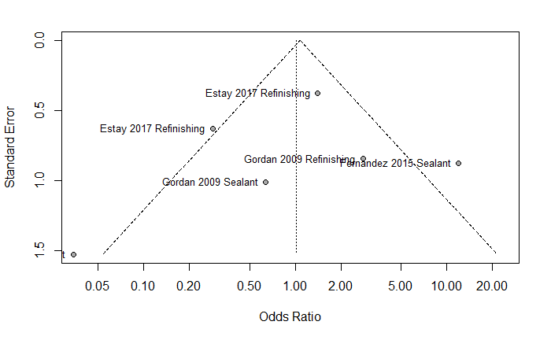

```r
funnel.meta(meta1,
            studlab = TRUE)
```

## Heterogeneity

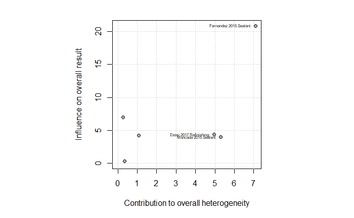

```r
baujat.meta(meta1,
            yscale = 10, xmin = 3, ymin = 10,
            cex.studlab = .50)
```

## Meta-analysis and forest plot

```r
summary(meta1)
```

```
Number of studies combined: k = 6

                         OR           95%-CI    z  p-value
Random effects model 1.0181 [0.3054; 3.3946] 0.03   0.9767

Quantifying heterogeneity:
 tau^2 = 1.5285; H = 1.95 [1.29; 2.95]; I^2 = 73.8% [40.2%; 88.5%]

Test of heterogeneity:
     Q d.f.  p-value
 19.10    5   0.0018

Details on meta-analytical method:
- Mantel-Haenszel method
- DerSimonian-Laird estimator for tau^2
- Continuity correction of 0.5 in studies with zero cell frequencies
```

```r
meta1
```

```
                             OR            95%-CI %W(random)
Gordan 2009 Sealant      0.6400 [0.0880;  4.6554]       14.8
Gordan 2009 Refinishing  2.8000 [0.5321; 14.7350]       16.8
Moncada 2015 Sealant     0.0345 [0.0017;  0.6894]        9.8
Estay 2017 Refinishing   0.2864 [0.0836;  0.9813]       19.6
Fernandez 2015 Sealant  12.0000 [2.1471; 67.0674]       16.4
Estay 2017 Refinishing   1.4082 [0.6730;  2.9464]       22.6

Number of studies combined: k = 6

                         OR           95%-CI    z  p-value
Random effects model 1.0181 [0.3054; 3.3946] 0.03   0.9767

Quantifying heterogeneity:
 tau^2 = 1.5285; H = 1.95 [1.29; 2.95]; I^2 = 73.8% [40.2%; 88.5%]

Test of heterogeneity:
     Q d.f.  p-value
 19.10    5   0.0018

Details on meta-analytical method:
- Mantel-Haenszel method
- DerSimonian-Laird estimator for tau^2
- Continuity correction of 0.5 in studies with zero cell frequencies
```

## Forest

```
Unknown or uninitialised column: '.subset'.
```

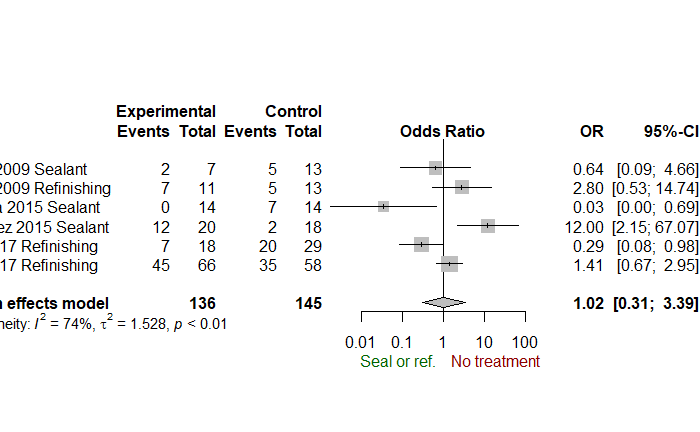

```r
forest.meta(meta1,
       comb.fixed = FALSE,
       sortvar = year,
       # LEFT
       label.left         = "Seal or ref.",
       col.label.left     = "darkgreen",
       # RIGHT
       label.right        = "No treatment",
       col.label.right    = "darkred")
```

## Export

```r
png(filename = "1.png",
    type = "cairo",
    units = "in",
    width = 10,
    height = 5,
    pointsize = 12,
    res = 96)
forest.meta(meta1,
       comb.fixed = FALSE,
       sortvar = year,
       # LEFT
       label.left         = "Seal or ref.",
       col.label.left     = "darkgreen",
       # RIGHT
       label.right        = "No treatment",
       col.label.right    = "darkred")
```

```
Unknown or uninitialised column: '.subset'.
```

```r
dev.off()
```

# 2. No-treatment SC (6)

## Data selection

```r
data_meta <- df %>%
  filter(groups == "No-treatment SC")
data_meta
```

| Comparison | Material | firstAuthor | year | paper | intervention_a | intervention_b | EvA | TotalA | EvB | TotalB | Outcome | id | groups |
| --- | --- | --- | --- | --- | --- | --- | --- | --- | --- | --- | --- | --- | --- |
| Sealants vs no-treatment Kz | Composite | Gordan | 2009 | b | Sealant | No-treatment | 0 | 7 | 1 | 13 | SC | Gordan , 2009 b | No-treatment SC |
| Refinishing vs no-treatment Kz | Composite | Gordan | 2009 | g | Refinishing | No-treatment | 1 | 11 | 1 | 13 | SC | Gordan , 2009 g | No-treatment SC |
| Sealants vs no-treatment Ag | Amalgam | Moncada | 2015 | e | Sealant | No-treatment | 0 | 14 | 1 | 14 | SC | Moncada , 2015 e | No-treatment SC |
| Refinishing vs no-treatment Kz | Composite | Estay | 2017 | k | Refinishing | No-treatment | 1 | 18 | 0 | 29 | SC | Estay , 2017 k | No-treatment SC |
| Sealants vs no-treatment Kz | Composite | Fernandez | 2015 | b | Sealant | No-treatment | 2 | 20 | 2 | 18 | SC | Fernandez , 2015 b | No-treatment SC |
| Refinishing vs no-treatment Ag | Amalgam | Estay | 2017 | h | Refinishing | No-treatment | 6 | 66 | 3 | 58 | SC | Estay , 2017 h | No-treatment SC |

```r
meta1 <- metabin(EvA, TotalA,
                 EvB, TotalB,
                 data = data_meta,
                 sm = "OR",  method.tau = "DL",
                 comb.fixed = FALSE,
                 studlab = paste(firstAuthor, year, intervention_a))
```

## Bias

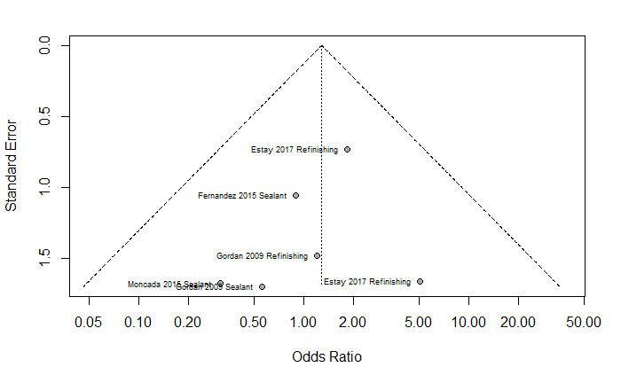

```r
funnel.meta(meta1,
            studlab = TRUE,
            cex.studlab = .55)
```

## Heterogeneity

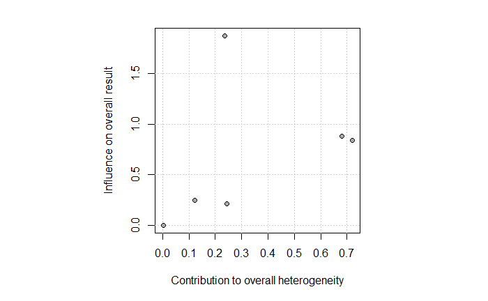

```r
baujat.meta(meta1,
            yscale = 10, xmin = 3, ymin = 10,
            cex.studlab = .50)
```

## Meta-analysis and forest plot

```r
summary(meta1)
```

```
Number of studies combined: k = 6

                        OR           95%-CI    z  p-value
Random effects model 1.286 [0.4991; 3.3137] 0.52   0.6024

Quantifying heterogeneity:
 tau^2 = 0; H = 1.00 [1.00; 1.26]; I^2 = 0.0% [0.0%; 36.7%]

Test of heterogeneity:
    Q d.f.  p-value
 2.00    5   0.8487

Details on meta-analytical method:
- Mantel-Haenszel method
- DerSimonian-Laird estimator for tau^2
- Continuity correction of 0.5 in studies with zero cell frequencies
```

```r
meta1
```

```
                            OR             95%-CI %W(random)
Gordan 2009 Sealant     0.5556 [0.0200;  15.4620]        8.1
Gordan 2009 Refinishing 1.2000 [0.0663;  21.7233]       10.7
Moncada 2015 Sealant    0.3103 [0.0116;   8.2917]        8.3
Estay 2017 Refinishing  5.0571 [0.1952; 131.0509]        8.5
Fernandez 2015 Sealant  0.8889 [0.1119;   7.0614]       20.9
Estay 2017 Refinishing  1.8333 [0.4372;   7.6869]       43.6

Number of studies combined: k = 6

                        OR           95%-CI    z  p-value
Random effects model 1.286 [0.4991; 3.3137] 0.52   0.6024

Quantifying heterogeneity:
 tau^2 = 0; H = 1.00 [1.00; 1.26]; I^2 = 0.0% [0.0%; 36.7%]

Test of heterogeneity:
    Q d.f.  p-value
 2.00    5   0.8487

Details on meta-analytical method:
- Mantel-Haenszel method
- DerSimonian-Laird estimator for tau^2
- Continuity correction of 0.5 in studies with zero cell frequencies
```

## Forest

```
Unknown or uninitialised column: '.subset'.
```

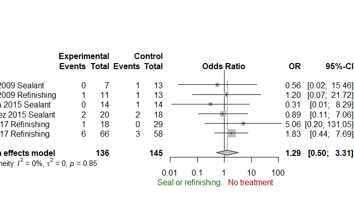

```r
forest.meta(meta1,
       comb.fixed = FALSE,
       sortvar = year,
       # LEFT
       label.left         = "Seal or refinishing",
       col.label.left     = "darkgreen",
       # RIGHT
       label.right        = "No treatment",
       col.label.right    = "darkred")
```

## Export

```r
png(filename = "2.png",
    type = "cairo",
    units = "in",
    width = 10,
    height = 5,
    pointsize = 12,
    res = 96)
forest.meta(meta1,
       comb.fixed = FALSE,
       sortvar = year,
       # LEFT
       label.left         = "Seal or refinishing",
       col.label.left     = "darkgreen",
       # RIGHT
       label.right        = "No treatment",
       col.label.right    = "darkred")
```

```
Unknown or uninitialised column: '.subset'.
```

```r
dev.off()
```

# 3. No-treatment TS (3)

## Data selection

```r
data_meta <- df %>%
  filter(groups == "No-treatment TS")
data_meta
```

| Comparison | Material | firstAuthor | year | paper | intervention_a | intervention_b | EvA | TotalA | EvB | TotalB | Outcome | id | groups |
| --- | --- | --- | --- | --- | --- | --- | --- | --- | --- | --- | --- | --- | --- |
| Sealants vs no-treatment Ag | Amalgam | Moncada | 2015 | f | Sealant | No-treatment | 1 | 14 | 1 | 14 | TS | Moncada , 2015 f | No-treatment TS |
| Refinishing vs no-treatment Kz | Composite | Estay | 2017 | l | Refinishing | No-treatment | 2 | 18 | 0 | 29 | TS | Estay , 2017 l | No-treatment TS |
| Refinishing vs no-treatment Ag | Amalgam | Estay | 2017 | i | Refinishing | No-treatment | 4 | 66 | 1 | 58 | TS | Estay , 2017 i | No-treatment TS |

```r
meta1 <- metabin(EvA, TotalA,
                 EvB, TotalB,
                 data = data_meta,
                 sm = "OR",  method.tau = "DL",
                 comb.fixed = FALSE,
                 studlab = paste(firstAuthor, year, intervention_a))
```

## Bias

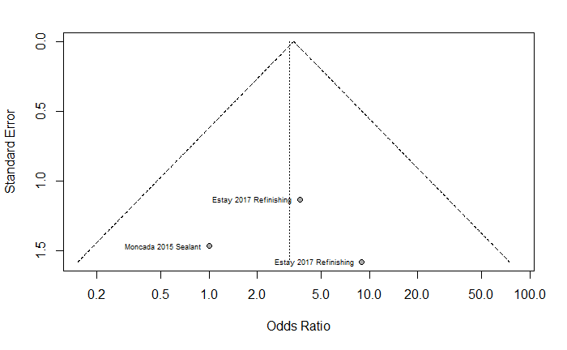

```r
funnel.meta(meta1,
            studlab = TRUE,
            cex.studlab = .55)
```

## Heterogeneity

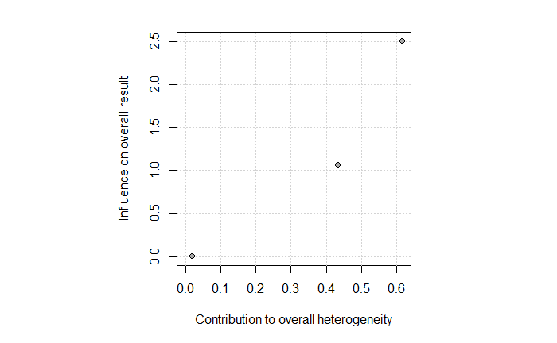

```r
baujat.meta(meta1,
            yscale = 10, xmin = 3, ymin = 10,
            cex.studlab = .50)
```

## Meta-analysis and forest plot

```r
summary(meta1)
```

```
Number of studies combined: k = 3

                         OR            95%-CI    z  p-value
Random effects model 3.1616 [0.6856; 14.5791] 1.48   0.1400

Quantifying heterogeneity:
 tau^2 = 0; H = 1.00 [1.00; 2.27]; I^2 = 0.0% [0.0%; 80.6%]

Test of heterogeneity:
    Q d.f.  p-value
 1.07    2   0.5850

Details on meta-analytical method:
- Mantel-Haenszel method
- DerSimonian-Laird estimator for tau^2
- Continuity correction of 0.5 in studies with zero cell frequencies
```

```r
meta1
```

```
                           OR             95%-CI %W(random)
Moncada 2015 Sealant   1.0000 [0.0563;  17.7510]       28.2
Estay 2017 Refinishing 8.9394 [0.4045; 197.5585]       24.4
Estay 2017 Refinishing 3.6774 [0.3992;  33.8804]       47.4

Number of studies combined: k = 3

                         OR            95%-CI    z  p-value
Random effects model 3.1616 [0.6856; 14.5791] 1.48   0.1400

Quantifying heterogeneity:
 tau^2 = 0; H = 1.00 [1.00; 2.27]; I^2 = 0.0% [0.0%; 80.6%]

Test of heterogeneity:
    Q d.f.  p-value
 1.07    2   0.5850

Details on meta-analytical method:
- Mantel-Haenszel method
- DerSimonian-Laird estimator for tau^2
- Continuity correction of 0.5 in studies with zero cell frequencies
```

## Forest

```
Unknown or uninitialised column: '.subset'.
```

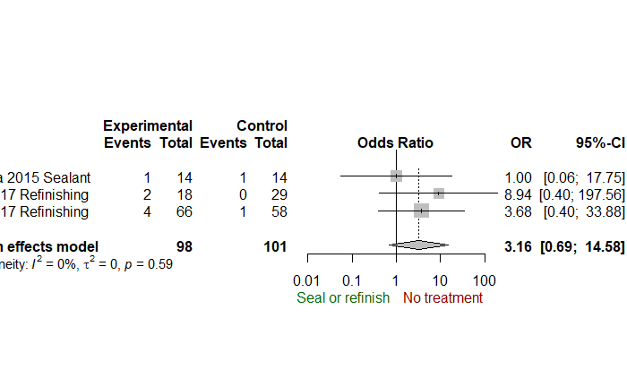

```r
forest.meta(meta1,
       comb.fixed = FALSE,
       sortvar = year,
       # LEFT
       label.left         = "Seal or refinish",
       col.label.left     = "darkgreen",
       # RIGHT
       label.right        = "No treatment",
       col.label.right    = "darkred")
```

## Export

```r
png(filename = "3.png",
    type = "cairo",
    units = "in",
    width = 10,
    height = 5,
    pointsize = 12,
    res = 96)
forest.meta(meta1,
       comb.fixed = FALSE,
       sortvar = year,
       # LEFT
       label.left         = "Seal or refinish",
       col.label.left     = "darkgreen",
       # RIGHT
       label.right        = "No treatment",
       col.label.right    = "darkred")
```

```
Unknown or uninitialised column: '.subset'.
```

```r
dev.off()
```

# 4. Replacement MA (5)

## Data selection

```r
data_meta <- df %>%
  filter(groups == "Replacement MA")
data_meta
```

| Comparison | Material | firstAuthor | year | paper | intervention_a | intervention_b | EvA | TotalA | EvB | TotalB | Outcome | id | groups |
| --- | --- | --- | --- | --- | --- | --- | --- | --- | --- | --- | --- | --- | --- |
| Repair vs replacement Ag | Amalgam | Gordan | 2011 | b | Repair | Replacement | 1 | 14 | 7 | 19 | MA | Gordan , 2011 b | Replacement MA |
| Sealants vs replacement Ag | Amalgam | Moncada | 2015 | a | Sealant | Replacement | 0 | 14 | 0 | 16 | MA | Moncada , 2015 a | Replacement MA |
| Repair vs replacement Kz | Composite | Estay | 2017 | d | Repair | Replacement | 8 | 14 | 15 | 22 | MA | Estay , 2017 d | Replacement MA |
| Repair vs replacement Ag | Amalgam | Estay | 2017 | a | Repair | Replacement | 7 | 18 | 4 | 21 | MA | Estay , 2017 a | Replacement MA |
| Repair vs replacement Kz | Composite | Gordan | 2009 | c | Repair | Replacement | 7 | 25 | 4 | 13 | MA | Gordan , 2009 c | Replacement MA |

```r
meta1 <- metabin(EvA, TotalA,
                 EvB, TotalB,
                 data = data_meta,
                 sm = "OR",  method.tau = "DL",
                 comb.fixed = FALSE,
                 studlab = paste(firstAuthor, year, intervention_a))
```

## Bias

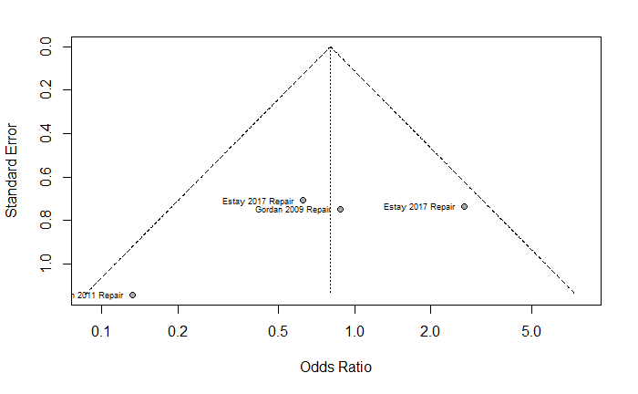

```r
funnel.meta(meta1,
            studlab = TRUE,
            cex.studlab = .55)
```

## Heterogeneity

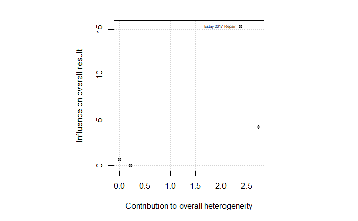

```r
baujat.meta(meta1,
            yscale = 10, xmin = 3, ymin = 10,
            cex.studlab = .50)
```

## Meta-analysis and forest plot

```r
summary(meta1)
```

```
Number of studies combined: k = 4

                         OR           95%-CI     z  p-value
Random effects model 0.7996 [0.2774; 2.3052] -0.41   0.6789

Quantifying heterogeneity:
 tau^2 = 0.5096; H = 1.34 [1.00; 2.31]; I^2 = 44.1% [0.0%; 81.3%]

Test of heterogeneity:
    Q d.f.  p-value
 5.37    3   0.1467

Details on meta-analytical method:
- Mantel-Haenszel method
- DerSimonian-Laird estimator for tau^2
```

```r
meta1
```

```
                         OR            95%-CI %W(random)
Gordan 2011 Repair   0.1319 [0.0141;  1.2354]       16.1
Moncada 2015 Sealant     NA                          0.0
Estay 2017 Repair    0.6222 [0.1554;  2.4920]       28.9
Estay 2017 Repair    2.7045 [0.6384; 11.4576]       27.7
Gordan 2009 Repair   0.8750 [0.2020;  3.7907]       27.3

Number of studies combined: k = 4

                         OR           95%-CI     z  p-value
Random effects model 0.7996 [0.2774; 2.3052] -0.41   0.6789

Quantifying heterogeneity:
 tau^2 = 0.5096; H = 1.34 [1.00; 2.31]; I^2 = 44.1% [0.0%; 81.3%]

Test of heterogeneity:
    Q d.f.  p-value
 5.37    3   0.1467

Details on meta-analytical method:
- Mantel-Haenszel method
- DerSimonian-Laird estimator for tau^2
```

## Forest

```
Unknown or uninitialised column: '.subset'.
```

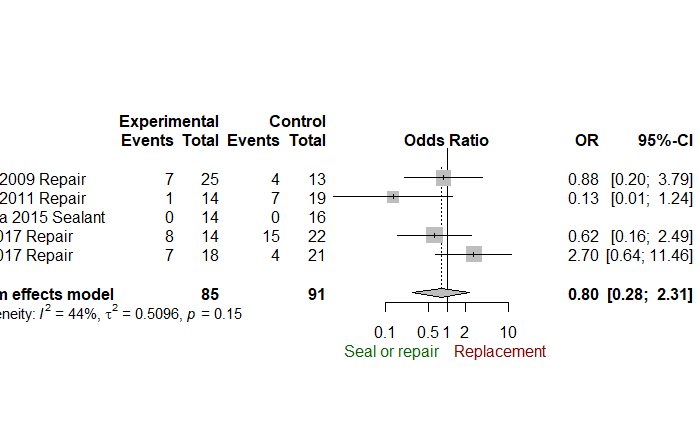

```r
forest.meta(meta1,
       comb.fixed = FALSE,
       sortvar = year,
       # LEFT
       label.left         = "Seal or repair",
       col.label.left     = "darkgreen",
       # RIGHT
       label.right        = "Replacement",
       col.label.right    = "darkred")
```

## Export

```r
png(filename = "4.png",
    type = "cairo",
    units = "in",
    width = 10,
    height = 5,
    pointsize = 12,
    res = 96)
forest.meta(meta1,
       comb.fixed = FALSE,
       sortvar = year,
       # LEFT
       label.left         = "Seal or repair",
       col.label.left     = "darkgreen",
       # RIGHT
       label.right        = "Replacement",
       col.label.right    = "darkred")
```

```
Unknown or uninitialised column: '.subset'.
```

```r
dev.off()
```

# 5. Replacement SC (5)

## Data selection

```r
data_meta <- df %>%
  filter(groups == "Replacement SC")
data_meta
```

| Comparison | Material | firstAuthor | year | paper | intervention_a | intervention_b | EvA | TotalA | EvB | TotalB | Outcome | id | groups |
| --- | --- | --- | --- | --- | --- | --- | --- | --- | --- | --- | --- | --- | --- |
| Repair vs replacement Ag | Amalgam | Gordan | 2011 | b | Repair | Replacement | 1 | 14 | 7 | 19 | SC | Gordan , 2011 b | Replacement SC |
| Sealants vs replacement Ag | Amalgam | Moncada | 2015 | b | Sealant | Replacement | 0 | 14 | 0 | 16 | SC | Moncada , 2015 b | Replacement SC |
| Repair vs replacement Kz | Composite | Estay | 2017 | e | Repair | Replacement | 3 | 14 | 1 | 22 | SC | Estay , 2017 e | Replacement SC |
| Repair vs replacement Ag | Amalgam | Estay | 2017 | b | Repair | Replacement | 2 | 18 | 0 | 21 | SC | Estay , 2017 b | Replacement SC |
| Repair vs replacement Kz | Composite | Gordan | 2009 | d | Repair | Replacement | 0 | 25 | 1 | 13 | SC | Gordan , 2009 d | Replacement SC |

```r
meta1 <- metabin(EvA, TotalA,
                 EvB, TotalB,
                 data = data_meta,
                 sm = "OR",  method.tau = "DL",
                 comb.fixed = FALSE,
                 studlab = paste(firstAuthor, year, intervention_a))
```

## Bias

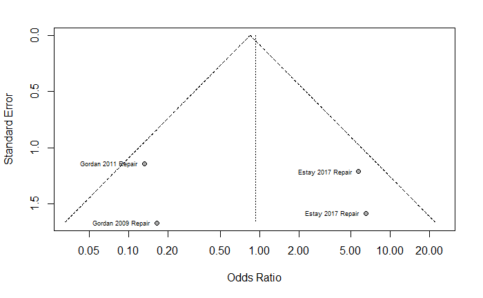

```r
funnel.meta(meta1,
            studlab = TRUE,
            cex.studlab = .55)
```

## Heterogeneity

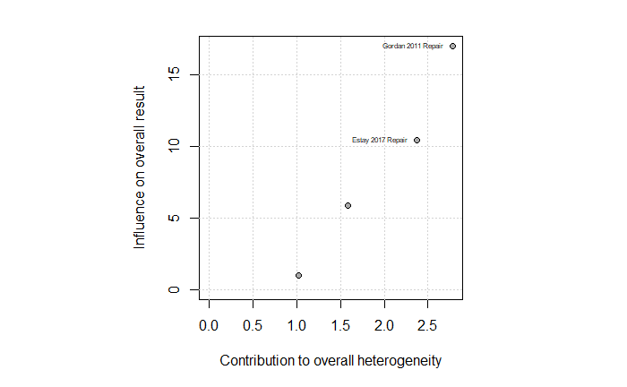

```r
baujat.meta(meta1,
            yscale = 10, xmin = 3, ymin = 10,
            cex.studlab = .50)
```

## Meta-analysis and forest plot

```r
summary(meta1)
```

```
Number of studies combined: k = 4

                         OR           95%-CI     z  p-value
Random effects model 0.9363 [0.1065; 8.2309] -0.06   0.9526

Quantifying heterogeneity:
 tau^2 = 2.9848; H = 1.61 [1.00; 2.78]; I^2 = 61.4% [0.0%; 87.1%]

Test of heterogeneity:
    Q d.f.  p-value
 7.77    3   0.0511

Details on meta-analytical method:
- Mantel-Haenszel method
- DerSimonian-Laird estimator for tau^2
- Continuity correction of 0.5 in studies with zero cell frequencies
```

```r
meta1
```

```
                         OR             95%-CI %W(random)
Gordan 2011 Repair   0.1319 [0.0141;   1.2354]       28.7
Moncada 2015 Sealant     NA                           0.0
Estay 2017 Repair    5.7273 [0.5312;  61.7487]       27.6
Estay 2017 Repair    6.5152 [0.2925; 145.1132]       22.4
Gordan 2009 Repair   0.1634 [0.0062;   4.3051]       21.3

Number of studies combined: k = 4

                         OR           95%-CI     z  p-value
Random effects model 0.9363 [0.1065; 8.2309] -0.06   0.9526

Quantifying heterogeneity:
 tau^2 = 2.9848; H = 1.61 [1.00; 2.78]; I^2 = 61.4% [0.0%; 87.1%]

Test of heterogeneity:
    Q d.f.  p-value
 7.77    3   0.0511

Details on meta-analytical method:
- Mantel-Haenszel method
- DerSimonian-Laird estimator for tau^2
- Continuity correction of 0.5 in studies with zero cell frequencies
```

## Forest

```
Unknown or uninitialised column: '.subset'.
```

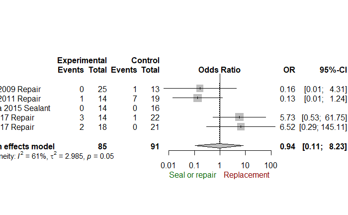

```r
forest.meta(meta1,
       comb.fixed = FALSE,
       sortvar = year,
       # LEFT
       label.left         = "Seal or repair",
       col.label.left     = "darkgreen",
       # RIGHT
       label.right        = "Replacement",
       col.label.right    = "darkred")
```

## Export

```r
png(filename = "5.png",
    type = "cairo",
    units = "in",
    width = 10,
    height = 5,
    pointsize = 12,
    res = 96)
forest.meta(meta1,
       comb.fixed = FALSE,
       sortvar = year,
       # LEFT
       label.left         = "Seal or repair",
       col.label.left     = "darkgreen",
       # RIGHT
       label.right        = "Replacement",
       col.label.right    = "darkred")
```

```
Unknown or uninitialised column: '.subset'.
```

```r
dev.off()
```

# 6. Replacement TS (5)

## Data selection

```r
data_meta <- df %>%
  filter(groups == "Replacement TS")
data_meta
```

| Comparison | Material | firstAuthor | year | paper | intervention_a | intervention_b | EvA | TotalA | EvB | TotalB | Outcome | id | groups |
| --- | --- | --- | --- | --- | --- | --- | --- | --- | --- | --- | --- | --- | --- |
| Repair vs replacement Ag | Amalgam | Gordan | 2011 | b | Repair | Replacement | 1 | 14 | 7 | 19 | TS | Gordan , 2011 b | Replacement TS |
| Sealants vs replacement Ag | Amalgam | Moncada | 2015 | c | Sealant | Replacement | 1 | 14 | 1 | 16 | TS | Moncada , 2015 c | Replacement TS |
| Repair vs replacement Kz | Composite | Estay | 2017 | f | Repair | Replacement | 0 | 14 | 0 | 22 | TS | Estay , 2017 f | Replacement TS |
| Repair vs replacement Ag | Amalgam | Estay | 2017 | c | Repair | Replacement | 1 | 18 | 2 | 21 | TS | Estay , 2017 c | Replacement TS |
| Repair vs replacement Kz | Composite | Gordan | 2009 | e | Repair | Replacement | 0 | 25 | 0 | 13 | TS | Gordan , 2009 e | Replacement TS |

```r
meta1 <- metabin(EvA, TotalA,
                 EvB, TotalB,
                 data = data_meta,
                 sm = "OR",  method.tau = "DL",
                 comb.fixed = FALSE,
                 studlab = paste(firstAuthor, year, intervention_a))
```

## Bias

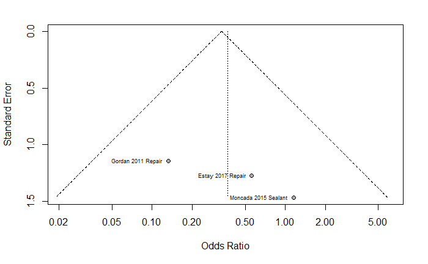

```r
funnel.meta(meta1,
            studlab = TRUE,
            cex.studlab = .55)
```

## Heterogeneity

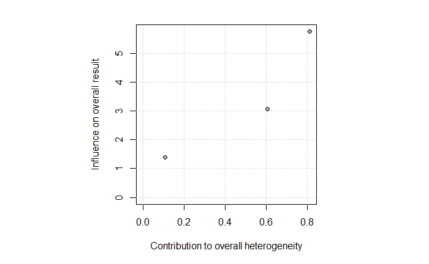

```r
baujat.meta(meta1,
            yscale = 10, xmin = 3, ymin = 10,
            cex.studlab = .50)
```

## Meta-analysis and forest plot

```r
summary(meta1)
```

```
Number of studies combined: k = 3

                        OR           95%-CI     z  p-value
Random effects model 0.369 [0.0875; 1.5561] -1.36   0.1745

Quantifying heterogeneity:
 tau^2 = 0; H = 1.00 [1.00; 2.73]; I^2 = 0.0% [0.0%; 86.5%]

Test of heterogeneity:
    Q d.f.  p-value
 1.55    2   0.4617

Details on meta-analytical method:
- Mantel-Haenszel method
- DerSimonian-Laird estimator for tau^2
```

```r
meta1
```

```
                         OR            95%-CI %W(random)
Gordan 2011 Repair   0.1319 [0.0141;  1.2354]       41.4
Moncada 2015 Sealant 1.1538 [0.0654; 20.3419]       25.2
Estay 2017 Repair        NA                          0.0
Estay 2017 Repair    0.5588 [0.0464;  6.7269]       33.5
Gordan 2009 Repair       NA                          0.0

Number of studies combined: k = 3

                        OR           95%-CI     z  p-value
Random effects model 0.369 [0.0875; 1.5561] -1.36   0.1745

Quantifying heterogeneity:
 tau^2 = 0; H = 1.00 [1.00; 2.73]; I^2 = 0.0% [0.0%; 86.5%]

Test of heterogeneity:
    Q d.f.  p-value
 1.55    2   0.4617

Details on meta-analytical method:
- Mantel-Haenszel method
- DerSimonian-Laird estimator for tau^2
```

## Forest

```
Unknown or uninitialised column: '.subset'.
```

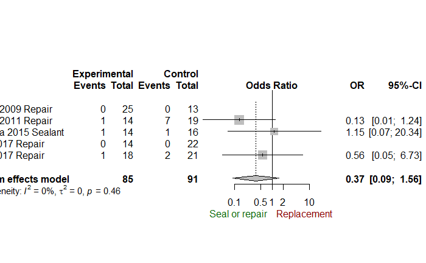

```r
forest.meta(meta1,
       comb.fixed = FALSE,
       sortvar = year,
       # LEFT
       label.left         = "Seal or repair",
       col.label.left     = "darkgreen",
       # RIGHT
       label.right        = "Replacement",
       col.label.right    = "darkred")
```

## Export

```r
png(filename = "6.png",
    type = "cairo",
    units = "in",
    width = 10,
    height = 5,
    pointsize = 12,
    res = 96)
forest.meta(meta1,
       comb.fixed = FALSE,
       sortvar = year,
       # LEFT
       label.left         = "Seal or repair",
       col.label.left     = "darkgreen",
       # RIGHT
       label.right        = "Replacement",
       col.label.right    = "darkred")
```

```
Unknown or uninitialised column: '.subset'.
```

```r
dev.off()
```

# Citations

```r
citation()
```

```
  R Core Team (2017). R: A language and environment for statistical computing. R Foundation for Statistical
  Computing, Vienna, Austria. URL https://www.R-project.org/.

A BibTeX entry for LaTeX users is

  @Manual{,
    title = {R: A Language and Environment for Statistical Computing},
    author = {{R Core Team}},
    organization = {R Foundation for Statistical Computing},
    address = {Vienna, Austria},
    year = {2017},
    url = {https://www.R-project.org/},
  }

We have invested a lot of time and effort in creating R, please cite it when using it for data analysis. See also
‘citation("pkgname")’ for citing R packages.
```

```r
citation(package = "tidyverse")
```

```
  Hadley Wickham (2017). tidyverse: Easily Install and Load the 'Tidyverse'. R package version 1.2.1.
  https://CRAN.R-project.org/package=tidyverse

A BibTeX entry for LaTeX users is

  @Manual{,
    title = {tidyverse: Easily Install and Load the 'Tidyverse'},
    author = {Hadley Wickham},
    year = {2017},
    note = {R package version 1.2.1},
    url = {https://CRAN.R-project.org/package=tidyverse},
  }
```

```r
citation(package = "meta")
```

```
  Guido Schwarzer (2007), meta: An R package for meta-analysis, R News, 7(3), 40-45.

A BibTeX entry for LaTeX users is

  @Article{,
    title = {meta: {A}n {R} package for meta-analysis},
    author = {Guido Schwarzer},
    journal = {R News},
    year = {2007},
    volume = {7},
    number = {3},
    pages = {40--45},
  }

URL https://cran.r-project.org/doc/Rnews/Rnews_2007-3.pdf
```